# Session 7 — Surveys, Survey Error & Sample Size

M731 Marketing Research · Chapters 8 and 12

Shay Abbasi

## Session 7

Surveys, survey error, and how big a sample you need

## Today’s agenda

1. Why surveys? Types of surveys (Ch 8)
2. Choosing a survey method — eight factors
3. Types of error in survey research
4. **Break (15 min)**
5. Sample size: budget, rules of thumb, subgroups (Ch 12)
6. Normal distribution, sampling distributions, standard error
7. Point vs. interval estimates — confidence intervals
8. Sample-size formulas for means and proportions
9. Finite population correction, sample units, power
10. Labs: Excel lab + R lab (sample size, CI, CLT simulation)

## Learning objectives

By the end of this session you will be able to:

- Compare survey methods and choose one for a given brief
- Classify survey errors as random or systematic, and name the specific type
- Explain the normal distribution, the central limit theorem, and standard error
- Build and interpret a confidence interval for a mean and a proportion
- Calculate the required sample size for a mean or a proportion, with and without the FPC
- Explain Type I / Type II error and statistical power

# Part 1 — Surveys (Ch 8)

## Why are surveys so popular?

Managers need to know:

1. **Why** people do or don’t do something
2. **How** decisions are made
3. **Who** is buying — demographic and lifestyle profile

Surveys collect all three at scale, with standardised questions that can be tabulated and tested.

## Types of surveys — the map

**Face-to-face**

- Door-to-door interviews
- Executive interviews (B2B, at place of business)
- Mall-intercept interviews

**Not face-to-face**

- Telephone — central-location / CATI
- Self-administered questionnaires (incl. kiosks)
- Mail surveys: **ad hoc** (one-shot) vs. **mail panels**
- Online surveys / panels

## Face-to-face methods

| Method | Where | Note |
| --- | --- | --- |
| Door-to-door | Respondent’s home | Rare in Canada today — cost, safety, nobody home |
| Executive | Respondent’s office | B2B equivalent of door-to-door; expensive, hard to schedule |
| Mall-intercept | Shopping mall / test area | Can show products, taste tests; **non-probability** sample |

## Telephone and self-administered methods

- **Central-location telephone**: interviewers work from one facility; supervisors can monitor unobtrusively
- **CATI** (computer-assisted telephone interviewing): questionnaire on screen, answers keyed directly, skip patterns automatic
- **Self-administered**: no interviewer — no interviewer bias, but no one to explain or probe
- **Mail — ad hoc**: one-shot mailing to a list, no prior contact
- **Mail panel**: pre-recruited respondents who agreed to take part for a period; much higher response rates

## Raising mail / online response rates

- Advance postcard, e-mail, or phone call
- Follow-up reminders
- Monetary incentives and premiums
- Personalised, signed cover letters
- Prize draws, charity donations
- University / research-institute affiliation
- Multiple mailings

**Academic research in focus:** a handwritten Post-it note asking people to complete the survey raised response rates more than the same message in a cover letter — and improved response quality.

## Ethics: respondents’ right to privacy

- Two dimensions of privacy: control of **unwanted intrusion** and control of **information about yourself**
- Online contact requires prior **opt-in** or an existing business relationship
- Respondent abuse: very long interviews, “nice-to-know” questions, selling data collected “for research”
- Refusal rates for phone surveys exceed 60%; long, personal surveys are a big reason

## Choosing a survey method — eight factors

| Factor | Question to ask |
| --- | --- |
| Sampling precision | How accurate must the result be? |
| Budget | How much money for fieldwork? |
| Respondent reactions | Must they taste, see, or handle something? |
| Quality of data | How valid and reliable must the data be? |
| Questionnaire length | How long does it take to complete? |
| Incidence rate | What % of people qualify? |
| Questionnaire structure | Mostly closed questions, or open and unstructured? |
| Time available | How fast are results needed? |

## Budget example

Interview budget $10,000; required sample n = 1,000.

| Method | Cost / interview | Total |
| --- | --- | --- |
| Mall intercept | $34.50 | $34,500 |
| Online survey | $1.50 | $1,500 |

Unless face-to-face contact is essential, the choice is clear.

## Strengths and weaknesses (data quality)

| Method | Strength | Weakness |
| --- | --- | --- |
| Mall intercept | Can show, explain, probe | Distractions, hurried respondents, interviewer bias, non-probability |
| Phone (central) | Supervision, good samples | Distractions, long/open questions hard, refusals |
| Self-administered | No interviewer bias, own pace | Can’t probe; non-response; who actually answered? |
| Mail | As self-administered | Better quality with mail panel |
| Online | Cheap, fast, personalised, reaches niche segments | Coverage — not everyone online; over-surveyed panels |

## Length, incidence, and time

- Ideal length (panel members’ view): **6–10 minutes** (44%), 2–5 min (21%), 11–15 min (21%)
- **Incidence rate** = % of the population who qualify. Low incidence → high search cost → online panels with prescreening are cheapest
- **Structure**: unstructured questionnaires need personal interviews
- **Time**: if results are needed fast, use the Internet

## Your turn — pick a method

A hardware store owner in Surrey, BC wants to know (1) the demographics of shoppers at his store vs. competitors and (2) his image vs. competitors. He has **three weeks** and a **limited budget**.

Which survey method would you recommend? Why?

# Part 2 — Errors in survey research

## Total survey error

```
Total survey error
├── Random error (chance variation) ── reduce only by increasing n
└── Systematic error (bias)
    ├── Sample design error
    │   ├── Frame error
    │   ├── Population specification error
    │   └── Selection error
    └── Measurement error
        ├── Surrogate information error
        ├── Interviewer error
        ├── Measurement instrument bias
        ├── Processing error
        ├── Non-response bias
        └── Response bias
```

## Random vs. systematic error

- **Random sampling error**: difference between a sample value and the true population value, due to **chance**. Cannot be eliminated; shrinks as n grows; can be **estimated** (margin of error)
- **Systematic error (bias)**: mistakes in design or execution that push results **consistently in one direction**. Sometimes called **non-sampling error**. More sample does **not** fix it

> “±3.1%, 19 times out of 20” covers **random sampling error only**. It says nothing about bias.

## Sample design errors

| Error | Cause | Example |
| --- | --- | --- |
| **Frame error** | Incomplete / inaccurate list | Phone directory as frame — misses unlisted and mobile-only households |
| **Population specification error** | Wrong definition of the population | “Snake owners” when it should be all reptile owners |
| **Selection error** | Sampling procedure not followed | Door-to-door interviewers skip untidy houses |

## Measurement errors (1/2)

- **Surrogate information error**: researcher seeks the wrong information. Kellogg’s *Ensemble* cereal — asked about lowering cholesterol, not whether people would *buy cereal* to do it
- **Interviewer error / bias**: interviewer influences answers (dress, tone, body language) or falsifies interviews
- **Measurement instrument (questionnaire) bias**: leading questions, confusing layout — fix with careful design and **pretesting**

## Measurement errors (2/2)

- **Processing error**: mistakes moving data from forms to the computer
- **Non-response bias**: people who respond differ systematically from those who don’t. Bank survey with <1% response: retirees over-represented 20×
  - Not reached · reached but busy · **refused** (worst)
  - **Refusal rate** = % of contacted people who refuse (≈64% in Canada, MRIA)
- **Response bias**: tendency to answer a certain way — deliberate falsification or unconscious misrepresentation

## How to minimise each error

| Error | Minimise by |
| --- | --- |
| Random | Increase sample size |
| Frame | Best frame available; check completeness |
| Population spec. | Define the population carefully |
| Selection | Random selection procedures + field quality checks |
| Surrogate info | Specify the information needed for the objectives |
| Interviewer | Selection, training, unobtrusive monitoring |
| Instrument | Careful questionnaire design + pretest |
| Processing | Rigid data-entry quality control |
| Non-response | Shorter surveys, callbacks, incentives, good timing |
| Response bias | Careful wording of sensitive / hard questions |

## Your turn — name that error

1. Survey on attitudes to city government using the **phone directory** as the frame
2. Interviewing only between **8 a.m. and 5 p.m.** about a new condo development
3. Asking whether people visited the public library in the **past two months**
4. Asking how many **tubes of toothpaste** they used in the past year
5. Telling interviewers they can **probe with any example they make up**

## Break — 15 minutes

# Part 3 — Sample size (Ch 12)

## The trade-off

- Larger sample → smaller sampling error, but **cost rises linearly**
- Sampling error falls with the **square root** of n
- **Quadruple** the sample → cost ×4, error only **halved**

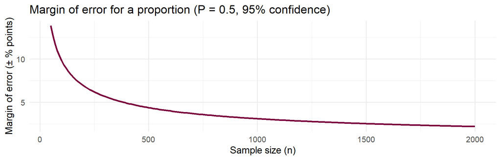

## Ways sample size gets decided

1. **Budget available** — what’s left after other costs. Unscientific but common
2. **Rule of thumb** — the client’s RFP says “n = 400”. Researcher must argue if it’s too small
3. **Number of subgroups analysed** — at least **100 per major subgroup**, **20–50 per minor subgroup**
4. **Traditional statistical methods** — need three inputs:
   - an estimate of the population standard deviation
   - the acceptable sampling error
   - the desired confidence level

## Subgroups example

n = 400, analysed by sex × age (under/over 35) → 4 cells of ~100.

Smaller cells → larger sampling error → harder to tell whether a gap between groups is real or chance.

> Plan the sample around the **smallest group you need to report on**, not the total.

## The normal distribution

- Bell-shaped, one mode, symmetric: **mean = median = mode**
- Defined by its mean (μ) and standard deviation (σ)
- Total area under the curve = 1
- Proportional property — the same share of area lies within k SDs of the mean for **every** normal distribution

| ±Z | Area |
| --- | --- |
| 1 | 68.26% |
| 2 | 95.44% |
| 3 | 99.74% |

## Standard normal distribution

$$Z = \frac{X - \mu}{\sigma}$$

- Mean 0, SD 1
- Converts any normal value to “how many SDs from the mean”
- Excel: `=STANDARDIZE(x, mean, sd)`, `=NORM.S.DIST(z, TRUE)`, `=NORM.S.INV(0.975)` → 1.96
- R: `pnorm(z)`, `qnorm(0.975)`

## Three distributions you must keep apart

| Distribution | What it is | Mean | SD |
| --- | --- | --- | --- |
| Population | All elements of the population | μ | σ |
| Sample | All elements of **one** sample | X̄ | S |
| Sampling distribution of the mean | Means of **all possible** samples of size n | μ | $S_{\bar{x}} = \sigma/\sqrt{n}$ |

The SD of the sampling distribution is the **standard error of the mean**.

## Central limit theorem

> For (almost) any population, the distribution of sample means becomes **normal** as n grows, centred on μ, with standard error σ/√n.
- Holds regardless of the population’s shape
- Text example: 1,000 samples of n = 200 fast-food users → the 1,000 sample means form a bell curve
- Formula applies to **simple random samples** only; stratified/cluster samples need more complex formulas

## CLT — watch it happen

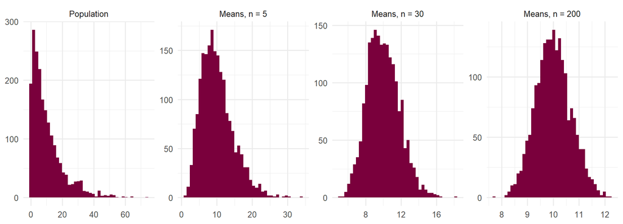

You will run this simulation yourself in both labs.

## Point and interval estimates

- **Point estimate**: the sample mean X̄ — one best guess
- **Interval estimate**: a range likely to contain μ
- **Confidence level**: probability the interval contains the true value (68.26%, 95.44%, 99.74% for ±1, 2, 3 SE)
- **Confidence interval**: X̄ ± Z · S<sub>x̄</sub>

$$\bar{X} - Z\,\frac{S}{\sqrt{n}} \le \mu \le \bar{X} + Z\,\frac{S}{\sqrt{n}}$$

σ is almost never known, so we estimate it with the sample SD, S.

## Sampling distribution of the proportion

For percentages (awareness, purchase, “yes” answers):

$$S_p = \sqrt{\frac{P(1-P)}{n}}$$

- Approximately normal, mean = population proportion
- CI: P ± Z · S<sub>p</sub>
- Researchers often prefer to size samples for **proportions** — see why in two slides

## Sample size for a mean

$$n = \frac{Z^2 \sigma^2}{E^2}$$

- **E** = allowable sampling error (set with the client)
- **Z** = confidence (1.96 or ~2 for 95%; 2.58 for 99%; 3 for 99.74%)
- **σ** = population SD — estimate from a **prior survey**, a **pilot**, **secondary data**, or **judgement**

**Fast-food example:** E = 0.1 visits, Z = 2, σ = 1.39

$$n = \frac{2^2 (1.39)^2}{0.1^2} = \frac{7.73}{0.01} \approx 772$$

## What if you don’t know σ?

σ is almost never known in advance — these are the practical workarounds:

- **Prior survey / published study** — use the SD reported there
- **Pilot study** — collect ~30 responses, use the sample SD *s* as σ
- **Range rule** — guess the plausible min and max; σ ≈ (max − min) / 4
  - 1–7 Likert → σ ≈ 1.5 · 1–10 scale → σ ≈ 2
- **Expert judgement** — ask people who know the market, then apply the range rule
- **Reframe as a proportion** — a “yes / no” version of the question lets you fall back on *P* = 0.5 (worst case) and skip σ

When in doubt, **overestimate** σ — safer to oversample than to under-power.

## Sample size for a proportion

$$n = \frac{Z^2 \, [P(1-P)]}{E^2}$$

**Online purchase example:** E = 0.04, Z = 2, P = 0.05 (last year’s study)

$$n = \frac{4 (0.05)(0.95)}{0.0016} = \frac{0.19}{0.0016} \approx 119$$

- No idea about P? Use **P = 0.5** — the worst case, gives the largest n
- There is **no** equivalent worst case for σ — another reason proportions are popular

## Margin of error at a glance (P = 0.5)

| n | 90% (Z=1.645) | 95% (Z=1.96) | 99% (Z=2.576) |
| --- | --- | --- | --- |
| 100 | ±8.2% | ±9.8% | ±12.9% |
| 400 | ±4.1% | ±4.9% | ±6.4% |
| 1,000 | ±2.6% | ±3.1% | ±4.1% |
| 2,000 | ±1.8% | ±2.2% | ±2.9% |

The RBC/Ipsos poll: n = 1,010 → ±3.1%, 19 times out of 20. Now you can check it.

## Reading a poll — Gallup 2012

- Obama 48%, Romney 49%, n = 3,117, ±2% at 95%
- Obama’s range: 46–50%; Romney’s: 47–51%
- Result: Obama 51% — **outside** the 95% interval
- Lesson: the fine print (margin, confidence, how the sample was drawn) matters as much as the headline — and random error is not the only error

## Population size and the FPC

- The formulas ignore population size — **usually that’s fine**
- Adjust only if the sample is **≥ 5% of the population**

$$n' = \frac{nN}{N + n - 1}$$

**Example:** N = 2,000, n = 400

$$n' = \frac{400 \times 2000}{2000 + 400 - 1} = \frac{800{,}000}{2{,}399} \approx 333$$

> What matters is whether the sample is **representative**, not its size relative to the population.

## Qualitative research and “the theory of thirty”

- Qualitative studies: responses tend to stabilise after **20–30** people. Formulas above don’t apply
- n = 30 is often treated as a minimum for quantitative work (CLT starts to bite), but the margin of error on a proportion is about **±18%**
- Whether that’s acceptable is a judgement about the decision at stake

## How many sample units do you need?

Target 400 completes — how many phone numbers (or e-mail invites)?

$$\text{Units needed} = \frac{\text{Completes}}{\text{working rate} \times \text{incidence} \times \text{completion rate}}$$

**ATM example:** 400 completes, 60% working numbers, 43% incidence, 35% agree:

$$\frac{400}{0.60 \times 0.43 \times 0.35} = \frac{400}{0.0903} \approx 4{,}430 \text{ numbers}$$

## Biased samples can’t be rescued

Radio station daytime phone poll on private health care:

- Landline only → misses younger, mobile-only residents
- Daytime → skews to homemakers, unemployed, retirees

A “statistically calculated” n means nothing if selection isn’t random.

## Hypothesis testing — H₀ and Hₐ

- **Null hypothesis (H₀)**: the status-quo claim — usually “no effect” or “equal to this value”
- **Alternative hypothesis (Hₐ)**: what we’d conclude if H₀ is implausible — the research claim
- We never *prove* H₀; we **reject** it or **fail to reject** it

**For a mean** — average weekly store visits:
$$H_0: \mu = 2.0 \qquad H_a: \mu \neq 2.0$$

**For a proportion** — brand awareness:
$$H_0: P = 0.30 \qquad H_a: P \neq 0.30$$

Compute a test statistic from the sample; if it’s extreme under H₀, reject.

## H₀ and Hₐ — one-sided vs. two-sided

Direction depends on the research question — what would make the manager act?

**Two-sided** (any difference matters):

- Average weekly visits: $H_0: \mu = 2.0$ · $H_a: \mu \neq 2.0$
- Brand awareness: $H_0: P = 0.30$ · $H_a: P \neq 0.30$

**One-sided** (only one direction matters):

- Did satisfaction *rise* above 7? $H_0: \mu \leq 7$ · $H_a: \mu > 7$
- Did refusal rate *fall* below 60%? $H_0: P \geq 0.60$ · $H_a: P < 0.60$

The **research claim** always sits in Hₐ. Pick direction **before** collecting the data.

## By number of variables — simple vs. complex

**Simple** — one IV, one DV:

- *The discount (IV) increases the sign-up rate (DV).*
- Formal: $H_0: P_\text{discount} = P_\text{regular}$ · $H_a: P_\text{discount} > P_\text{regular}$
- Tested with a two-proportions Z test or an independent-samples t test

**Complex** — multiple IVs or DVs:

- *The discount AND the ad channel (Instagram vs. email) jointly affect sign-up rate AND 3-month retention.*
- Tested with multiple regression, factorial ANOVA, or multivariate models (Sessions 10–11)

Start simple. Add complexity only when the business question demands it — and your sample can support it.

## By kind of relationship — associative vs. causal

**Associative** — variables move together; no claim about which drives which:

- *Regions where the brand runs more promotions also have higher sign-up rates.*
- Observed in sales data — no manipulation
- Tested with correlation, chi-square, cross-tabs

**Causal** — one variable *produces* a change in the other:

- *Offering the discount causes more sign-ups.*
- Tested with a **randomised A/B test** on the checkout page
- Needs an experiment (Session 10)

Observational data can suggest association. Only an experiment can prove cause.

## By number of groups — one, two, or more

**One group** — compare a sample to a known value or standard:

- *Is our average waiting time different from the promised 2 minutes?*
- $H_0: \mu = 2$ · $H_a: \mu \neq 2$ (two-sided) or $H_a: \mu > 2$ (one-sided)
- **One-sample** t test or Z test

**Two groups** — compare two samples:

- *Do men and women spend differently per visit?* **independent**
- *Did ratings change after the campaign?* **paired** (same people, twice)
- $H_0: \mu_1 = \mu_2$ · $H_a: \mu_1 \neq \mu_2$

**Three or more groups** — compare several samples:

- *Do satisfaction scores differ across Discovery, Standard, and Signature tiers?*
- $H_0: \mu_1 = \mu_2 = \mu_3$ · $H_a:$ at least one differs
- **One-way ANOVA**

## Which test? A one-page map

Pick by **what you’re comparing** (rows) and **the scale of your outcome** (columns).

| Comparison | Interval / Ratio | Ordinal | Nominal (counts) |
| --- | --- | --- | --- |
| 1 sample vs. a value | one-sample t | Wilcoxon signed-rank | 1-proportion Z · χ² goodness-of-fit |
| 2 independent groups | independent-samples t | Mann-Whitney U | 2-proportions Z · 2×2 χ² |
| 2 paired observations | paired-samples t | Wilcoxon signed-rank | McNemar’s test |
| 3+ independent groups | one-way ANOVA | Kruskal-Wallis | r × c χ² |
| Relationship between 2 vars | Pearson r | Spearman ρ | χ² independence |
| X predicts Y | linear regression | — | logistic regression |

Session 9 drills each row. Excel and R implementations in the labs.

## Type I, Type II, and power

|  | Fail to reject H₀ | Reject H₀ |
| --- | --- | --- |
| H₀ true | Correct (1 − α) | **Type I error (α)** |
| H₀ false | **Type II error (β)** | Correct (1 − β) = **power** |

- Court analogy: convicting an innocent person = Type I; letting a guilty person go = Type II
- Standard sample-size formulas implicitly assume **50% power**

## Power changes the sample size

Sample size **per group** to detect a difference between two proportions (around 50%), α = 0.05:

| Difference | 50% | 70% | 80% | 90% |
| --- | --- | --- | --- | --- |
| 0.01 | 19,205 | 30,857 | 39,239 | 52,530 |
| 0.05 | 766 | 1,231 | 1,568 | 2,094 |
| 0.10 | 190 | 305 | 389 | 518 |
| 0.15 | 83 | 133 | 169 | 226 |

R: `power.prop.test(p1 = .50, p2 = .55, power = .80)` · Excel: we build the formula in the lab.

## The law of small numbers

Male:female in Canada ≈ 50:50. Sample A has n = 100, Sample B has n = 1,000.

Which is more likely to be 60% men?

**Sample A.** Small samples swing more. Believing small samples mirror the population (gambler’s fallacy) leads to Type I errors.

# Part 4 — Practice

## Worked problems (from the text)

1. 80% of consumers like curly fries. You want a standard error ≤ 6% and 95% confidence. What n?
2. Chili cook-off: 99% confidence, error < 4 oz, last year’s σ = 3 oz. What n?
3. Client wants 99.74% confidence, ±2% error → n = 500 at $20,000. Budget is $17,000. Options?
4. Canadian Film & Music study: n = 2,002 → ±2.2%. Verify it. What would the margin be at 99%? What n keeps ±2.2% at 99%?

## Labs this week

- **Excel lab** (`session-07-ExcelLab.html` + `session-07-ExcelLab.xlsx`)
  - Z-scores and normal areas, CI calculator, sample-size calculator, FPC, sample units, power table, drawing random / systematic / stratified samples, CLT simulation
- **R lab** (`session-07-RLab.html`)
  - Same tasks in R on `maritime_survey.csv`, plus writing your own sample-size functions and a non-response-bias simulation

## For your project

- Which survey method are you using, and why — against the eight factors?
- List the **three biggest error risks** in your design and how you’ll reduce them
- Calculate your target n (mean or proportion), state E, Z, and your σ / P source
- Work back from completes to the number of invitations you need to send

## Next session

Session 8 — Chapter 13: data processing (validation, editing, coding, entry, cleaning), tabulation and cross-tabs, descriptive statistics, and the logic of hypothesis testing.